# Case Study: Credit Scoring

Máster en Data Science y Big Data en Finanzas

AFI, 2022

# Motivation

When a bank receives a loan application, based on the applicant’s profile, the bank has to make a decision regarding whether to go ahead with the loan approval or not. Two types of risks are associated with the bank’s decision:

- If the applicant has a good credit risk, i.e. is likely to repay the loan, then not approving the loan to the client results in a loss of business to the bank
- If the applicant has a bad credit risk, i.e. is not likely to repay the loan, then approving the loan to the client results in a financial loss to the bank

To minimize loss from the bank’s perspective, the bank needs a decision rule regarding who to give approval of the loan and who not to

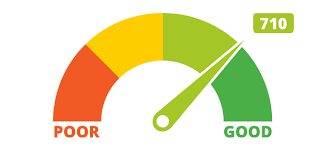

An applicant’s demographic and socio-economic profiles are considered by loan managers before a decision is taken regarding his/her loan application.

**Goal:** Predict whether or not somebody will experience financial distress in the future

The credit score is then estimated by the probability of default based on historical data

### Available Data

The Credit Scoring dataset contains data on 10 predictors and the objective is, using these predictors, to predict the probability that somebody will experience financial distress in the next two years.

Data can be found in Kaggle: https://www.kaggle.com/c/GiveMeSomeCredit/overview

### Load useful libraries

```r
library(tidyverse)
library(skimr)
library(mice)
library(VIM)
library(GGally)
library(MASS)
library(glmnet)
library(e1071)
library(rpart)
library(pROC)
library(class)
library(randomForest)
library(caret)
```

# Load and explore the data set

```r
dataCredit<-read.csv("credit-scoring.csv", header = TRUE, sep = ",")

glimpse(dataCredit)
```

```
## Rows: 150,000
## Columns: 12
## $ Id                                   <int> 1, 2, 3, 4, 5, 6, 7, 8, 9, 10, 11~
## $ SeriousDlqin2yrs                     <int> 1, 0, 0, 0, 0, 0, 0, 0, 0, 0, 0, ~
## $ RevolvingUtilizationOfUnsecuredLines <dbl> 0.76612661, 0.95715102, 0.6581801~
## $ age                                  <int> 45, 40, 38, 30, 49, 74, 57, 39, 2~
## $ NumberOfTime30.59DaysPastDueNotWorse <int> 2, 0, 1, 0, 1, 0, 0, 0, 0, 0, 0, ~
## $ DebtRatio                            <dbl> 8.029821e-01, 1.218762e-01, 8.511~
## $ MonthlyIncome                        <int> 9120, 2600, 3042, 3300, 63588, 35~
## $ NumberOfOpenCreditLinesAndLoans      <int> 13, 4, 2, 5, 7, 3, 8, 8, 2, 9, 5,~
## $ NumberOfTimes90DaysLate              <int> 0, 0, 1, 0, 0, 0, 0, 0, 0, 0, 0, ~
## $ NumberRealEstateLoansOrLines         <int> 6, 0, 0, 0, 1, 1, 3, 0, 0, 4, 0, ~
## $ NumberOfTime60.89DaysPastDueNotWorse <int> 0, 0, 0, 0, 0, 0, 0, 0, 0, 0, 0, ~
## $ NumberOfDependents                   <int> 2, 1, 0, 0, 0, 1, 0, 0, NA, 2, 0,~
```

Variable ‘SeriousDlqin2yrs’ contains the labels: whether a person experienced 90 days past due delinquency or worse

Features or explanatory variables or predictors:

- RevolvingUtilizationOfUnsecuredLines: Total balance on credit cards and personal lines of credit except real estate and no installment debt like car loans divided by the sum of credit limits
- age: Age of borrower in years
- NumberOfTime30-59DaysPastDueNotWorse: Number of times borrower has been 30-59 days past due but no worse in the last 2 years.
- DebtRatio: Monthly debt payments, alimony,living costs divided by monthly gross income
- MonthlyIncome: Monthly income
- NumberOfOpenCreditLinesAndLoans: Number of Open loans (installment like car loan or mortgage) and Lines of credit (e.g. credit cards)
- NumberOfTimes90DaysLate: Number of times borrower has been 90 days or more past due.
- NumberRealEstateLoansOrLines: Number of mortgage and real estate loans including home equity lines of credit
- NumberOfTime60-89DaysPastDueNotWorse: Number of times borrower has been 60-89 days past due but no worse in the last 2 years.
- NumberOfDependents: Number of dependents in family excluding themselves (spouse, children etc.)

Remove Id column and rename the target

```r
dataCredit <- dataCredit[,-1]
names(dataCredit)[1] = "Creditability"
dataCredit$Creditability = as.factor(dataCredit$Creditability)
levels(dataCredit$Creditability)=c("Good", "Bad")
```

Split data into training and testing sets

```r
in_train <- createDataPartition(dataCredit$Creditability, p = 0.2, list = FALSE)  # 20% for training
training <- dataCredit[ in_train,]
testing <- dataCredit[-in_train,]
nrow(training)
```

```
## [1] 30001
```

```r
nrow(testing)
```

```
## [1] 119999
```

```r
table(training$Creditability)/length(training$Creditability)
```

```
##
##       Good        Bad
## 0.93313556 0.06686444
```

93% good loans, 7% bad loans: unbalanced dataset

### Data cleaning and Feature Engineering

Take a look first:

```r
summary(training)
```

```
##  Creditability RevolvingUtilizationOfUnsecuredLines      age
##  Good:27995    Min.   :    0.000                    Min.   :21.00
##  Bad : 2006    1st Qu.:    0.030                    1st Qu.:41.00
##                Median :    0.155                    Median :52.00
##                Mean   :    6.508                    Mean   :52.21
##                3rd Qu.:    0.555                    3rd Qu.:63.00
##                Max.   :22000.000                    Max.   :99.00
##
##  NumberOfTime30.59DaysPastDueNotWorse   DebtRatio         MonthlyIncome
##  Min.   : 0.0000                      Min.   :     0.00   Min.   :      0
##  1st Qu.: 0.0000                      1st Qu.:     0.18   1st Qu.:   3352
##  Median : 0.0000                      Median :     0.37   Median :   5363
##  Mean   : 0.4698                      Mean   :   346.33   Mean   :   6630
##  3rd Qu.: 0.0000                      3rd Qu.:     0.88   3rd Qu.:   8194
##  Max.   :98.0000                      Max.   :106885.00   Max.   :3008750
##                                                           NA's   :5950
##  NumberOfOpenCreditLinesAndLoans NumberOfTimes90DaysLate
##  Min.   : 0.000                  Min.   : 0.0000
##  1st Qu.: 5.000                  1st Qu.: 0.0000
##  Median : 8.000                  Median : 0.0000
##  Mean   : 8.436                  Mean   : 0.3147
##  3rd Qu.:11.000                  3rd Qu.: 0.0000
##  Max.   :50.000                  Max.   :98.0000
##
##  NumberRealEstateLoansOrLines NumberOfTime60.89DaysPastDueNotWorse
##  Min.   : 0.000               Min.   : 0.000
##  1st Qu.: 0.000               1st Qu.: 0.000
##  Median : 1.000               Median : 0.000
##  Mean   : 1.015               Mean   : 0.285
##  3rd Qu.: 2.000               3rd Qu.: 0.000
##  Max.   :25.000               Max.   :98.000
##
##  NumberOfDependents
##  Min.   : 0.0000
##  1st Qu.: 0.0000
##  Median : 0.0000
##  Mean   : 0.7611
##  3rd Qu.: 1.0000
##  Max.   :10.0000
##  NA's   :768
```

Insights?

Perform some data exploration for predictors

```r
# Insert your code here
```

Some cleaning:

There are strange categories like 96 and 98

```r
table(training$NumberOfTime30.59DaysPastDueNotWorse)
```

```
##
##     0     1     2     3     4     5     6     7     8     9    10    12    96
## 25162  3236   906   344   174    58    29    12     4     5     2     1     1
##    98
##    67
```

```r
table(training$NumberOfTime60.89DaysPastDueNotWorse)
```

```
##
##     0     1     2     3     4     5     6     7    96    98
## 28485  1144   213    65    14     6     4     2     1    67
```

```r
table(training$NumberOfTimes90DaysLate)
```

```
##
##     0     1     2     3     4     5     6     7     8     9    10    14    17
## 28283  1059   340   130    50    31    19     7     9     2     1     1     1
##    96    98
##     1    67
```

Hence, replace coded values “96” and “98” with 0

```r
training$NumberOfTime30.59DaysPastDueNotWorse[training$NumberOfTime30.59DaysPastDueNotWorse==96] <- 0
training$NumberOfTime30.59DaysPastDueNotWorse[training$NumberOfTime30.59DaysPastDueNotWorse==98] <- 0
training$NumberOfTime60.89DaysPastDueNotWorse[training$NumberOfTime60.89DaysPastDueNotWorse==96] <- 0
training$NumberOfTime60.89DaysPastDueNotWorse[training$NumberOfTime60.89DaysPastDueNotWorse==98] <- 0
training$NumberOfTimes90DaysLate[training$NumberOfTimes90DaysLate==96] <- 0
training$NumberOfTimes90DaysLate[training$NumberOfTimes90DaysLate==98] <- 0

testing$NumberOfTime30.59DaysPastDueNotWorse[testing$NumberOfTime30.59DaysPastDueNotWorse==96] <- 0
testing$NumberOfTime30.59DaysPastDueNotWorse[testing$NumberOfTime30.59DaysPastDueNotWorse==98] <- 0
testing$NumberOfTime60.89DaysPastDueNotWorse[testing$NumberOfTime60.89DaysPastDueNotWorse==96] <- 0
testing$NumberOfTime60.89DaysPastDueNotWorse[testing$NumberOfTime60.89DaysPastDueNotWorse==98] <- 0
testing$NumberOfTimes90DaysLate[testing$NumberOfTimes90DaysLate==96] <- 0
testing$NumberOfTimes90DaysLate[testing$NumberOfTimes90DaysLate==98] <- 0
```

```r
if(sum(training$NumberRealEstateLoansOrLines==54)>0){
  training<-training[-(which(training$NumberRealEstateLoansOrLines==54)),]
}
```

### Missing values

```r
# Insert your code here
```

We can create a knn imputation model on the training data

And use the imputation model to predict the values of missing data points

```r
preProcess_missingdata <- preProcess(training, method='knnImpute')
library(RANN)  # required for knnInpute
training.imp <- predict(preProcess_missingdata, newdata = training)
anyNA(training.imp)
```

Less sophisticated ideas:

```r
# Replace NA in NumberOfDependents with 0
training$NumberOfDependents[is.na(training$NumberOfDependents)] <- 0
testing$NumberOfDependents[is.na(testing$NumberOfDependents)] <- 0

# Imputation with median
training$MonthlyIncome = ifelse(is.na(training$MonthlyIncome), median(training$MonthlyIncome, na.rm=TRUE), training$MonthlyIncome)
# note we impute NA in testing with info from training
testing$MonthlyIncome = ifelse(is.na(testing$MonthlyIncome), median(training$MonthlyIncome, na.rm=TRUE), testing$MonthlyIncome)
```

Even easier but more dangerous:

```r
na.omit(training)
```

### Correlations between predictors

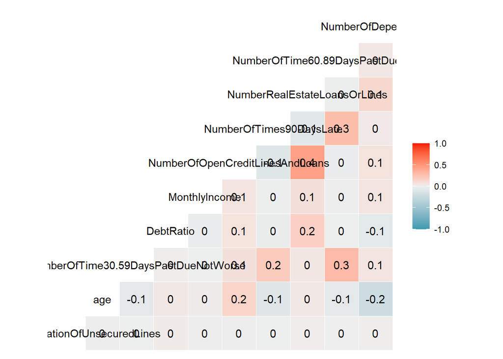

```r
ggcorr(training[,-1], label = T)
```

Moderate correlations

# Modeling

### Logistic regression

Because we have binary classification, we can use the standard glm function in R:

```r
logit.model <- glm(Creditability ~ ., family=binomial(link='logit'), data=training)
summary(logit.model)
```

```
##
## Call:
## glm(formula = Creditability ~ ., family = binomial(link = "logit"),
##     data = training)
##
## Deviance Residuals:
##     Min       1Q   Median       3Q      Max
## -4.5147  -0.3467  -0.2776  -0.2208   2.9700
##
## Coefficients:
##                                        Estimate Std. Error z value Pr(>|z|)
## (Intercept)                          -1.559e+00  1.005e-01 -15.520  < 2e-16 ***
## RevolvingUtilizationOfUnsecuredLines  4.730e-05  8.027e-05   0.589  0.55569
## age                                  -2.903e-02  2.010e-03 -14.445  < 2e-16 ***
## NumberOfTime30.59DaysPastDueNotWorse  5.544e-01  2.464e-02  22.502  < 2e-16 ***
## DebtRatio                            -2.370e-05  2.402e-05  -0.987  0.32388
## MonthlyIncome                        -3.675e-05  7.689e-06  -4.780 1.76e-06 ***
## NumberOfOpenCreditLinesAndLoans      -1.661e-02  6.187e-03  -2.685  0.00726 **
## NumberOfTimes90DaysLate               8.564e-01  3.783e-02  22.637  < 2e-16 ***
## NumberRealEstateLoansOrLines          1.378e-01  2.491e-02   5.533 3.15e-08 ***
## NumberOfTime60.89DaysPastDueNotWorse  6.958e-01  5.299e-02  13.132  < 2e-16 ***
## NumberOfDependents                    4.694e-02  2.183e-02   2.150  0.03156 *
## ---
## Signif. codes:  0 '***' 0.001 '**' 0.01 '*' 0.05 '.' 0.1 ' ' 1
##
## (Dispersion parameter for binomial family taken to be 1)
##
##     Null deviance: 14728  on 30000  degrees of freedom
## Residual deviance: 12049  on 29990  degrees of freedom
## AIC: 12071
##
## Number of Fisher Scoring iterations: 6
```

### Interpretation

Example: for every year change in the variable age, the logs odds of Creditability decreases by -0.03. Better taking exponentials (odd ratios)

```r
exp(coef(logit.model))
```

```
##                          (Intercept) RevolvingUtilizationOfUnsecuredLines
##                            0.2103347                            1.0000473
##                                  age NumberOfTime30.59DaysPastDueNotWorse
##                            0.9713858                            1.7409414
##                            DebtRatio                        MonthlyIncome
##                            0.9999763                            0.9999633
##      NumberOfOpenCreditLinesAndLoans              NumberOfTimes90DaysLate
##                            0.9835251                            2.3547338
##         NumberRealEstateLoansOrLines NumberOfTime60.89DaysPastDueNotWorse
##                            1.1477657                            2.0053615
##                   NumberOfDependents
##                            1.0480559
```

And vice versa: ff age decreases by 10 years, then the odds increases by $\exp(-0.03\times -10)=1.35$ (a 35%)

Summary: an odds ratio of 1 indicates no change, whereas an odds ratio of 2 indicates a doubling, and 0.5 indicates halving, etc.

### Predictions

Make predictions (posterior probabilities)

```r
probability <- predict(logit.model,newdata=testing, type='response')
head(probability)
```

```
##           2           3           4           5           6           7
## 0.055444148 0.198389431 0.066961498 0.008641928 0.024101133 0.036766995
```

```r
prediction <- as.factor(ifelse(probability > 0.5,"Bad","Good"))
head(prediction)
```

```
##    2    3    4    5    6    7
## Good Good Good Good Good Good
## Levels: Bad Good
```

Performance: confusion matrix

```r
# Type your code here for the confusion matrix
confusionMatrix(prediction, testing$Creditability)
```

```
## Confusion Matrix and Statistics
##
##           Reference
## Prediction   Good    Bad
##       Good 111205   6870
##       Bad     774   1150
##
##                Accuracy : 0.9363
##                  95% CI : (0.9349, 0.9377)
##     No Information Rate : 0.9332
##     P-Value [Acc > NIR] : 6.186e-06
##
##                   Kappa : 0.2109
##
##  Mcnemar's Test P-Value : < 2.2e-16
##
##             Sensitivity : 0.9931
##             Specificity : 0.1434
##          Pos Pred Value : 0.9418
##          Neg Pred Value : 0.5977
##              Prevalence : 0.9332
##          Detection Rate : 0.9267
##    Detection Prevalence : 0.9840
##       Balanced Accuracy : 0.5682
##
##        'Positive' Class : Good
##
```

Note the previous threshold=0.5 is indeed an hyper-parameter. How to optimize it?

If the bank is more worried about false Creditable loans (financial loss) than false non-Creditable ones (loss of business), then in the confusion matrix, better to decrease the element (1,2) at the cost of increasing the (2,1)

### Penalized logistic regression

When the dimension is high, it is better to use a penalized version. The most known is glmnet or elasticnet.

```r
logit.model <- glmnet(as.matrix(training[,-1]),training$Creditability, family=c("binomial"), alpha=0, lambda=0.01)

probability <- predict(logit.model,as.matrix(testing[,-1]), type='response')

prediction <- as.factor(ifelse(probability > 0.5,"Bad","Good"))

confusionMatrix(prediction, testing$Creditability)
```

```
## Confusion Matrix and Statistics
##
##           Reference
## Prediction   Good    Bad
##       Good 111297   6981
##       Bad     682   1039
##
##                Accuracy : 0.9361
##                  95% CI : (0.9347, 0.9375)
##     No Information Rate : 0.9332
##     P-Value [Acc > NIR] : 1.676e-05
##
##                   Kappa : 0.1943
##
##  Mcnemar's Test P-Value : < 2.2e-16
##
##             Sensitivity : 0.9939
##             Specificity : 0.1296
##          Pos Pred Value : 0.9410
##          Neg Pred Value : 0.6037
##              Prevalence : 0.9332
##          Detection Rate : 0.9275
##    Detection Prevalence : 0.9857
##       Balanced Accuracy : 0.5617
##
##        'Positive' Class : Good
##
```

The previous alpha and lambda are indeed hyper-parameters. How to optimize them?

### The ROC curve

ROC curve shows true positives vs false positives in relation with different thresholds:

- y-axis = Sensitivity (TP)
- x-axis = Specificity (1-FP)

Choose here any model:

```r
model <- glm(Creditability ~ ., family=binomial(link='logit'), data=training)
```

Obtain posterior probabilities and compute the ROC

```r
probability = predict(model, testing, type = 'response')

roc.lda <- roc(testing$Creditability,probability)
auc(roc.lda)
```

```
## Area under the curve: 0.8069
```

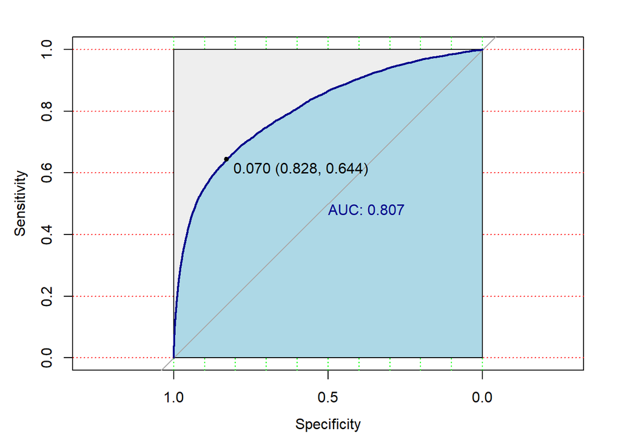

```r
plot.roc(testing$Creditability, probability,col="darkblue", print.auc = TRUE,  auc.polygon=TRUE, grid=c(0.1, 0.2),
         grid.col=c("green", "red"), max.auc.polygon=TRUE,
         auc.polygon.col="lightblue", print.thres=TRUE)
```

AUD = Area Under the Curve: 0.81, the larger the better. Maximum is 1

Seems a threshold around 0.1 is reasonable

- this is because classes are unbalanced
- this is the threshold with the best balance between sensitivity and specificity
- but is it the optimal threshold for the company?

# Incorporing economic impact

A naive-manager classifier: all loans are approved, the only error (7%) comes from the false creditable loans (there are no false non-creditable loans)

We can reduce the false positives by decreasing the probability threshold

And we can select the optimal threshold using some specific economic effects

Assume the bank predicts an application to be credit-worthy and it actually turns out to be credit worthy. That implies, for that application, a 12% profit at the end of 2 years

On the other hand, if the application turns out to be a default, then the loss is 100%

If the bank predicts an application to be non-creditworthy, then the profit is 0% if the application turns out to be a default, but there is an opportunity loss (1% in 2 years) if the application is really credit-worthy

Table of profits:

| Prediction/Reference | Good | Bad |
| --- | --- | --- |
| Good | 0.12 | -1.0 |
| Bad | -0.01 | 0.0 |

For instance, a naive manager would incur a profit per applicant of $0.12\times0.93 - 1.0\times0.07 - 0.01\times0.0 + 0.0\times0.0 = 0.0416$

This is the profit we should improve

Profit table as a vector:

```r
profit.unit <- c(0.12, -0.01, -1.0, 0.0)
```

What is the profit of our last model but with the Bayes’ rule?

```r
threshold = 0.5

Cred.pred = rep("Good", nrow(testing))
Cred.pred[which(probability > threshold)] = "Bad"
CM = confusionMatrix(factor(Cred.pred), testing$Creditability)$table
```

```r
profit.applicant <- sum(profit.unit*CM)/sum(CM)
profit.applicant
```

```
## [1] 0.05389095
```

If the average loan amount is 15000 euros, and there are over 10000 applicants in one month then this is the expected profit in 2 years for the applicants in one month:

```r
profit.applicant*15000*10000
```

```
## [1] 8083642
```

But this is for threshold=0.5

With this economic information, how to select the optimal threshold?

### Selecting the optimal threshold to give the loan

```r
profit.i = matrix(NA, nrow = 50, ncol = 10)
# 50 replicates for training/testing sets for each of the 10 values of threshold

j <- 0
for (threshold in seq(0.05,0.5,0.05)){
  #for (p1 in c(0.1, 0.2, 0.3, 0.4, 0.5, 0.6, 0.7, 0.75, 0.8, 0.9)){

  j <- j + 1
  cat(j)
  for(i in 1:50){

    # partition data intro training (40%) and testing sets (60%)
    d <- createDataPartition(training$Creditability, p = 0.4, list = FALSE)
    # select training sample

    train<-training[d,]
    test <-training[-d,]

    full.model = glm(Creditability ~ ., family=binomial(link='logit'), data=train)

    # probabilities
    probability = predict(full.model, test, type="response")

    # Predictions with a given threshold
    Cred.pred = rep("Good", nrow(test))
    Cred.pred[which(probability > threshold)] = "Bad"

    CM = confusionMatrix(factor(Cred.pred), test$Creditability)$table

    profit.applicant <- sum(profit.unit*CM)/sum(CM)
    profit.i[i,j] <- profit.applicant

  }
}
```

```
## 12345678910
```

```r
#podemos seguir ajustando

profit.i = matrix(NA, nrow = 50, ncol = 6)
# 50 replicates for training/testing sets for each of the 10 values of threshold

j <- 0
for (threshold in seq(0.05,0.15,0.02)){
  #for (p1 in c(0.1, 0.2, 0.3, 0.4, 0.5, 0.6, 0.7, 0.75, 0.8, 0.9)){

  j <- j + 1
  cat(j)
  for(i in 1:50){

    # partition data intro training (40%) and testing sets (60%)
    d <- createDataPartition(training$Creditability, p = 0.4, list = FALSE)
    # select training sample

    train<-training[d,]
    test <-training[-d,]

    full.model = glm(Creditability ~ ., family=binomial(link='logit'), data=train)

    # probabilities
    probability = predict(full.model, test, type="response")

    # Predictions with a given threshold
    Cred.pred = rep("Good", nrow(test))
    Cred.pred[which(probability > threshold)] = "Bad"

    CM = confusionMatrix(factor(Cred.pred), test$Creditability)$table

    profit.applicant <- sum(profit.unit*CM)/sum(CM)
    profit.i[i,j] <- profit.applicant

  }
}
```

```
## 123456
```

Summary of economic value of predictions

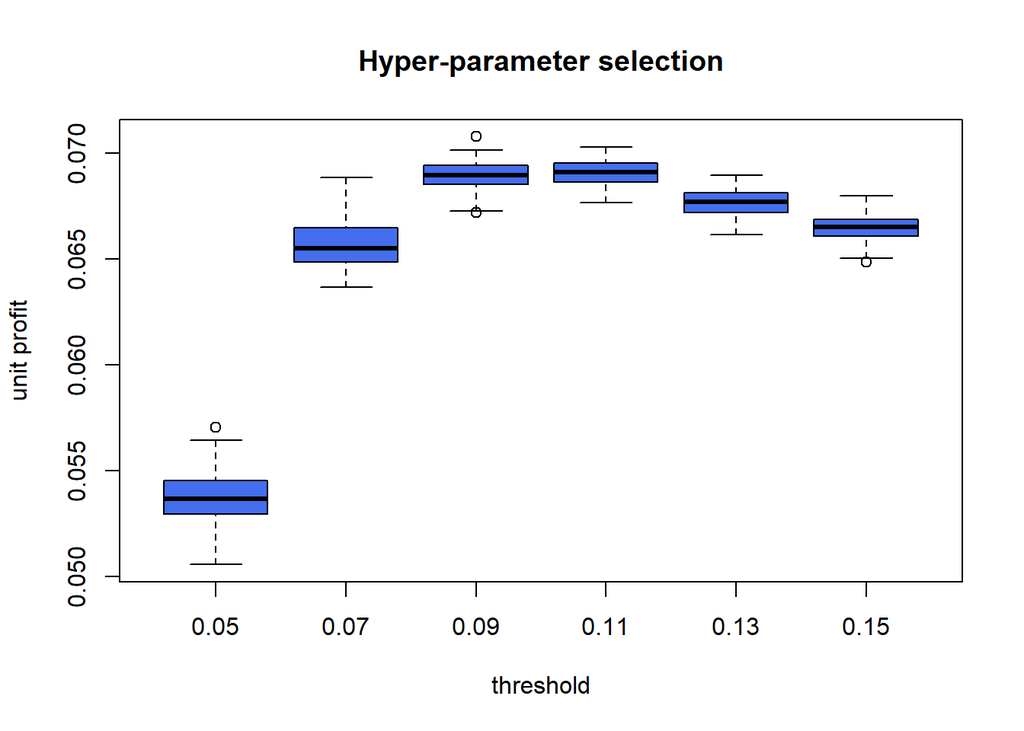

```r
boxplot(profit.i, main = "Hyper-parameter selection",
        ylab = "unit profit",
        xlab = "threshold",names = seq(0.05,0.15,0.02),col="royalblue2")
```

threshold values around 0.1 are reasonable:

```r
apply(profit.i, 2, median)
```

```
## [1] 0.05366083 0.06549000 0.06895083 0.06909889 0.06767472 0.06651194
```

### Final prediction for testing set using the optimal hyper-parameter:

```r
final.model = glm(Creditability ~ ., family=binomial(link='logit'), data=training)

probability = predict(final.model, newdata=testing, type="response")
threshold = 0.1

Cred.pred = rep("Good", nrow(testing))
Cred.pred[which(probability > threshold)] = "Bad"
CM = confusionMatrix(factor(Cred.pred), testing$Creditability)$table
profit.applicant <- sum(profit.unit*CM)/sum(CM)
profit.applicant
```

```
## [1] 0.06983525
```

```r
profit.applicant*15000*10000
```

```
## [1] 10475287
```